# Lecture 09 playground

```r
library(tidyverse)
library(car)
library(performance)
library(patchwork)
```

idea:

- sim data that violates normality of errors and homosced.
- have students identify those errors based on diagnostic plots
- bootstrap data from this dataset
- plot it and see if those assumptions change

# Sim violating data

Something different with the errors this time. Give students new illustration of how things can diverge from normality. Not asymmetrical, but maybe U-shaped errors? As in, mostly large in both directions, not usually small?

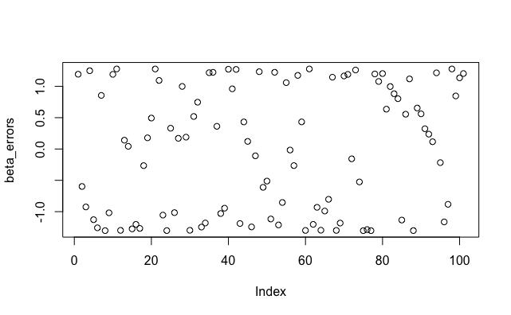

```r
shapes <- .3
set.seed(1)
beta_errors <- rbeta(101, shape1 = shapes, shape2 = shapes) |>
  datawizard::standardize()
  # scale(scale = FALSE, center = TRUE)
plot(beta_errors)
```

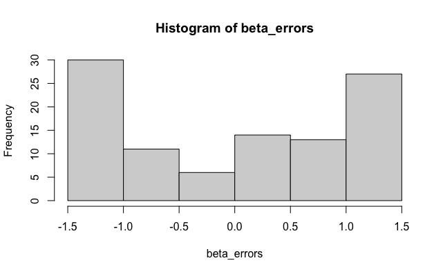

```r
hist(beta_errors)
```

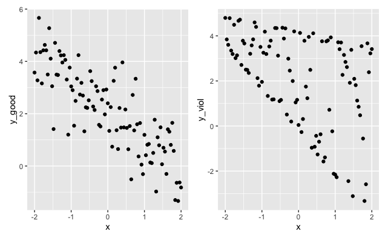

```r
set.seed(1)

error_inc_terms <- seq(.5, 3, length.out = 101)

df <- tibble(
  x = seq(-2, 2, length.out = 101),
  y_good = 2 + (-1.1 * x) + rnorm(101, 0, 1),
  y_viol = 2 + (-1.1 * x) + beta_errors * error_inc_terms,
)

p_good <- df |>
  ggplot(aes(x=x, y=y_good)) +
  geom_point() +
  # geom_smooth(method = 'lm', se = FALSE) +
  NULL


p_beta <- df |>
  ggplot(aes(x=x, y=y_viol)) +
  geom_point() +
  # geom_smooth(method = 'lm', se = FALSE) +
  NULL

p_good + p_beta
```

## Fit models

```r
m_good <- lm(y_good ~ x, data = df)
m_viol <- lm(y_viol ~ x, data = df)
```

```r
summary(m_viol)
```

```
Call:
lm(formula = y_viol ~ x, data = df)

Residuals:
    Min      1Q  Median      3Q     Max
-4.0231 -1.3473  0.3146  1.5062  3.0814

Coefficients:
            Estimate Std. Error t value Pr(>|t|)
(Intercept)   2.1154     0.1846  11.459  < 2e-16 ***
x            -0.8130     0.1583  -5.136 1.41e-06 ***
---
Signif. codes:  0 ‘***’ 0.001 ‘**’ 0.01 ‘*’ 0.05 ‘.’ 0.1 ‘ ’ 1

Residual standard error: 1.855 on 99 degrees of freedom
Multiple R-squared:  0.2104,    Adjusted R-squared:  0.2024
F-statistic: 26.38 on 1 and 99 DF,  p-value: 1.408e-06
```

## Plot diagnostics

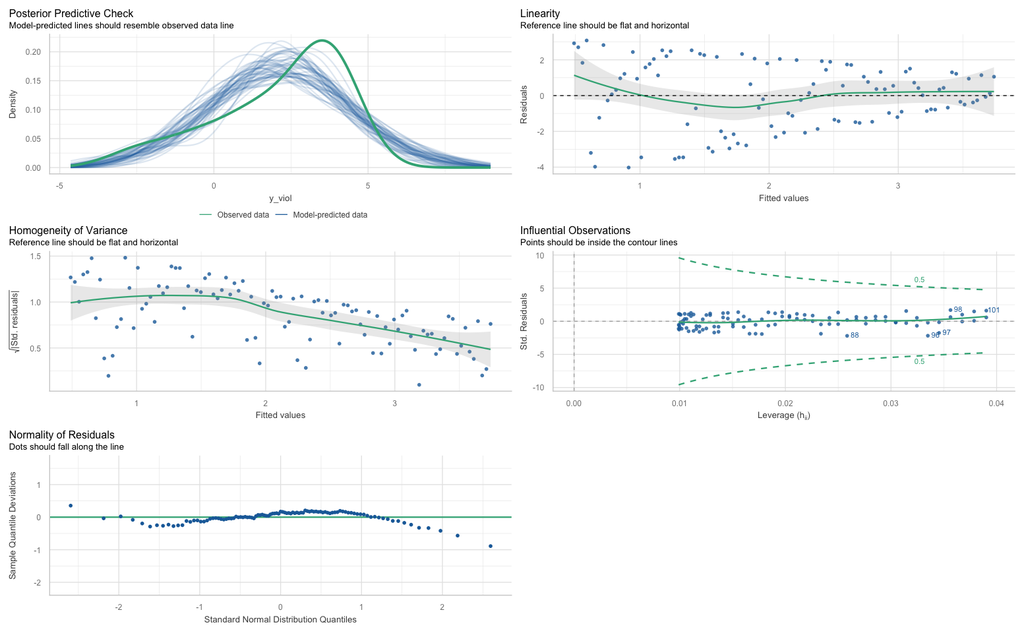

```r
check_model(m_viol)
```

### Q-Q plot

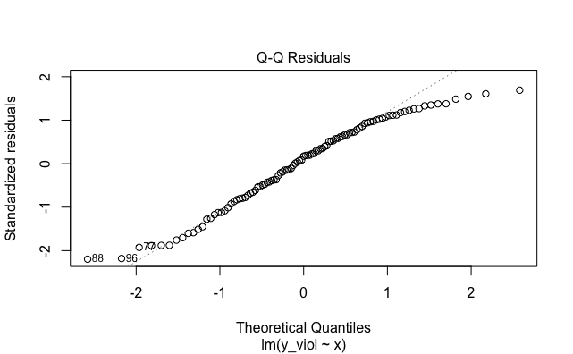

```r
plot(m_viol, which = 2)
```

### Histogram of residuals

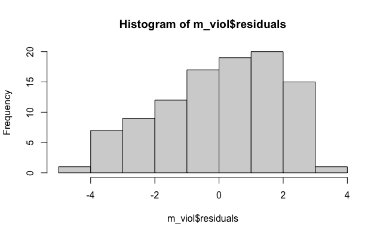

```r
hist(m_viol$residuals)
```

It’s really interesting how the model can find a line such that the residuals look almost gaussian, even though the generative process was so far from gaussian.

### Compare residuals to fitted values

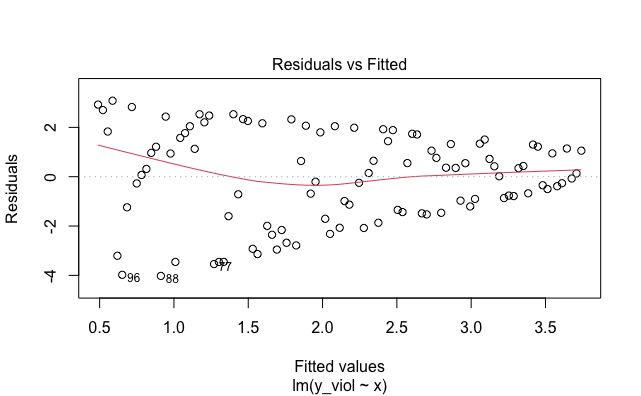

```r
plot(m_viol, which = 1)
```

# car::Boot()

## fit model

In reality, present this after showing the manual process.

`Boot()` draws `R` samples with the same number of observations as the original dataset.

```r
set.seed(1)
m_viol_boot <- Boot(m_viol, R = 1000)
summary(m_viol_boot)
```

```
Number of bootstrap replications R = 1000
            original    bootBias  bootSE  bootMed
(Intercept)  2.11540  0.00524979 0.18235  2.13003
x           -0.81301 -0.00071738 0.16164 -0.81038
```

```r
summary(m_viol)$coefficients
```

```
              Estimate Std. Error   t value     Pr(>|t|)
(Intercept)  2.1153955  0.1846088 11.458803 7.444834e-20
x           -0.8130144  0.1583007 -5.135886 1.408443e-06
```

```r
Confint(m_viol_boot, level = 0.95, type = 'perc')
```

```
Bootstrap percent confidence intervals
```

|  | Estimate | 2.5 % | 97.5 % |
| --- | --- | --- | --- |
| (Intercept) | 2.1153955 | 1.759312 | 2.4752116 |
| x | -0.8130144 | -1.146819 | -0.5242398 |

Consequently, the CIs are narrower for the bootstrapped model than they are for the original model. Original CIs:

```r
Confint(m_viol, level = 0.95, type = 'perc')
```

```
              Estimate     2.5 %     97.5 %
(Intercept)  2.1153955  1.749092  2.4816994
x           -0.8130144 -1.127117 -0.4989114
```

## plot diagnostics?

Doesn’t make a ton of sense because doesn’t really rely on same assumptions as the parametric version of the model.

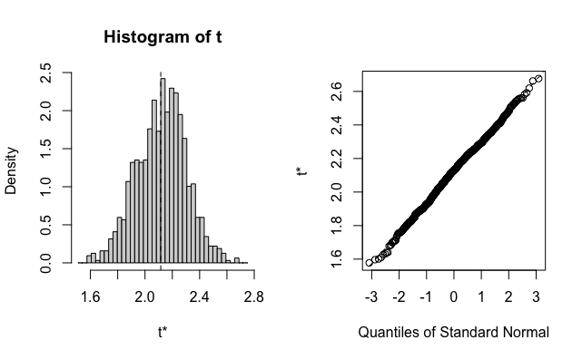

```r
plot(m_viol_boot)
```

Interesting, so apparently we want the t-values to be normally distributed.

`check_model()` throws an error.

```r
# check_model(m_viol_boot)
```

## fail: emmeans doesn’t work on boot object.

```r
# m_viol_emm <- emmeans( ref_grid(m_viol, at = list(x = c(-2, -1, 0, 1, 2))), ~x)
# m_viol_emm |> as.data.frame()
```

```r
# m_viol_boot_emm <- emmeans( ref_grid(m_viol_boot, at = list(x = c(-2, -1, 0, 1, 2))), ~x)
```

# Manually bootstrap from this data

- bootstrap sample
- fit model to that data
- gather values of important coefs
- make distrib of those coefs
- summarise those distribs
- that’s what the model is doing

```r
orig_data <- df |>
  select(x, y_viol) |>
  rename(y = y_viol) |>
  rowid_to_column()

boot_sample_size <- nrow(orig_data)
n_resamples <- 100
```

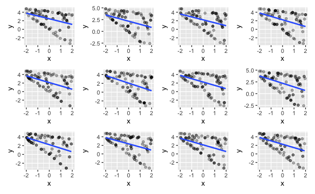

```r
draw_boot_samples <- function(dataset, resample_size, n_resamples){
  # dataset: dataframe or tibble
  # resample_size: integer, size of the sample to draw
  # n_resamples: integer, number of bootstrap samples to draw
  # returns list with each element a subset of dataset

  boot_accum <- list()
  for(i in 1:n_resamples){
    boot_accum[[i]] <- dataset |>
      slice_sample(n = resample_size, replace = TRUE)
  }
  return(boot_accum)
}


plot_boot_sample <- function(boot_sample){
  # boot_sample: dataset, outcome of draw_boot_sample
  boot_sample |>
    ggplot(aes(x = x, y = y)) +
    geom_point(alpha = 0.3) +
    geom_smooth(method = 'lm', se = FALSE) +
    xlim(-2, 2) +
    NULL

}

set.seed(1)
boot_samples <- draw_boot_samples(orig_data, boot_sample_size, n_resamples)
boot_plot_list <- lapply(boot_samples, plot_boot_sample)

# plot_boot_sample(boot_samples[[1]])
wrap_plots(boot_plot_list[1:12])
```

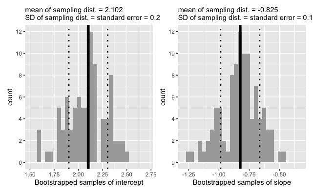

```r
fit_lm <- function(boot_sample){
  # boot_sample: df with cols x, y
  # returns coefs of LM fit to boot_sample

  m <- lm(y ~ x, data = boot_sample)
  return(m$coefficients)
}

# fit_lm(boot_samples[[1]])
boot_coefs <- lapply(boot_samples, fit_lm)
boot_coefs_df <- boot_coefs |>
  bind_rows(.id = 'boot_idx')

boot_int_mean <- mean(boot_coefs_df$`(Intercept)`)
boot_int_sd <- sd(boot_coefs_df$`(Intercept)`)
boot_slp_mean <- mean(boot_coefs_df$x)
boot_slp_sd <- sd(boot_coefs_df$x)

p_intercept <- boot_coefs_df |>
  ggplot(aes(x = `(Intercept)`)) +
  geom_histogram(fill = 'darkgrey') +
  geom_vline(xintercept = boot_int_mean, linewidth = 2, colour = 'black') +
  labs(
    x = 'Bootstrapped samples of intercept',
    subtitle = paste0('mean of sampling dist. = ', round(boot_int_mean, 3), '\nSD of sampling dist. = standard error = ', round(boot_int_sd, 3))
  ) +
  geom_vline(xintercept = boot_int_mean + boot_int_sd, linewidth = 1, colour = 'black', linetype = 'dotted') +
  geom_vline(xintercept = boot_int_mean - boot_int_sd, linewidth = 1, colour = 'black', linetype = 'dotted') +
  # geom_vline(xintercept = boot_int_mean + 1.96*boot_int_sd, linewidth = 1, colour = 'black', linetype = 'dotted') +
  # geom_vline(xintercept = boot_int_mean - 1.96*boot_int_sd, linewidth = 1, colour = 'black', linetype = 'dotted') +
  # geom_function(fun = function(x) dnorm(x, mean = boot_int_mean, sd = boot_int_sd) * 3, colour = 'black') +
  xlim(1.51, 2.71) +
  scale_y_continuous(limits = c(0, 12), breaks = seq(0, 12, by = 2)) +
  NULL

p_slope <- boot_coefs_df |>
  ggplot(aes(x = x)) +
  geom_histogram(fill = 'darkgrey') +
  geom_vline(xintercept = boot_slp_mean, linewidth = 2, colour = 'black') +
  labs(
    x = 'Bootstrapped samples of slope',
    subtitle = paste0('mean of sampling dist. = ', round(boot_slp_mean, 3), '\nSD of sampling dist. = standard error = ', round(boot_slp_sd, 3))
  ) +
  geom_vline(xintercept = boot_slp_mean + boot_slp_sd, linewidth = 1, colour = 'black', linetype = 'dotted') +
  geom_vline(xintercept = boot_slp_mean - boot_slp_sd, linewidth = 1, colour = 'black', linetype = 'dotted') +
  # geom_vline(xintercept = boot_slp_mean + 1.96*boot_slp_sd, linewidth = 1, colour = 'black', linetype = 'dotted') +
  # geom_vline(xintercept = boot_slp_mean - 1.96*boot_slp_sd, linewidth = 1, colour = 'black', linetype = 'dotted') +
  # geom_function(fun = function(x) dnorm(x, mean = boot_slp_mean, sd = boot_slp_sd) * 20, colour = 'black') +
  xlim(-1.29, -0.33) +
  scale_y_continuous(limits = c(0, 12), breaks = seq(0, 12, by = 2)) +
  NULL

p_intercept + p_slope
```

^ would be cool to animate the way these sampling distributions change as samples trickle in, the way I did for bayes_stat.

## animate boot using gifski

```r
boot_coefs_df <- boot_coefs_df |>
  rename(Intercept = `(Intercept)`)
```

Produce a list of ggplots, each of which is one frame of the animation.

```r
plot_limits <- list(
  'Intercept' = c(1.51, 2.71),
  'x' = c(-1.29, -0.33)
)
```

```r
gen_boot_plots <- function(all_boot_data, plot_limits, param_to_plot){
  # all_boot_data: dataset of the full sampling distribution
  #                must contain col boot_idx
  # plot_limits: list with upper and lower bounds of xlim for each param
  # param_to_plot: string, the parameter we want to get the samples of

  n_boot_samples <- nrow(all_boot_data)
  # n_boot_samples <- 3

  for(i in 1:n_boot_samples){

    curr_data <- all_boot_data |>
      slice_head(n = i) |>
      select(boot_idx, all_of(param_to_plot))

    curr_mean <- curr_data |>
      pull(param_to_plot) |>
      mean()

    curr_sd <- curr_data |>
      pull(param_to_plot) |>
      sd()

    # print()

    # Make current plot
    p <- curr_data |>
      ggplot(aes_string(x = param_to_plot)) +
      geom_histogram(fill = 'darkgrey', bins = 30) +
      geom_vline(xintercept = curr_mean, linewidth = 2, colour = 'black') +
      labs(
        title = paste0(param_to_plot, '\nNumber of bootstrapped samples = ', i),
        x = 'Mean of bootstrapped samples',
        subtitle = paste0('Mean of sampling dist. = ', round(curr_mean, 3), '\nSD of sampling dist. = standard error = ', round(curr_sd, 3))
      ) +
      geom_vline(xintercept = curr_mean + curr_sd, linewidth = 1, colour = 'black', linetype = 'dotted') +
      geom_vline(xintercept = curr_mean - curr_sd, linewidth = 1, colour = 'black', linetype = 'dotted') +
      xlim(
        plot_limits[[param_to_plot]][1],
        plot_limits[[param_to_plot]][2]
      ) +
      scale_y_continuous(limits = c(0, 12), breaks = seq(0, 12, by = 2)) +
      NULL

    print(p)

  }
}

# # will print 100 plots
# gen_boot_plots(boot_coefs_df, plot_limits, 'Intercept')
```

```r
# Intercept GIF
gifski::save_gif(
  gen_boot_plots(boot_coefs_df, plot_limits, 'Intercept'),
  'boot-int.gif',
  width = 600,
  height = 720,
  res = 144,
  delay = 0.2
)

# Slope GIF
gifski::save_gif(
  gen_boot_plots(boot_coefs_df, plot_limits, 'x'),
  'boot-slp.gif',
  width = 600,
  height = 720,
  res = 144,
  delay = 0.2
)
```

```r
library(gapminder)
library(ggplot2)
makeplot <- function(){
  datalist <- split(gapminder, gapminder$year)
  lapply(datalist, function(data){
    p <- ggplot(data, aes(gdpPercap, lifeExp, size = pop, color = continent)) +
      scale_size("population", limits = range(gapminder$pop)) + geom_point() + ylim(20, 90) +
      scale_x_log10(limits = range(gapminder$gdpPercap)) + ggtitle(data$year) + theme_classic()
    print(p)
  })
}

gif_file <- file.path('./gapminder.gif')
gifski::save_gif(makeplot(), gif_file, 1280, 720, res = 144, delay=0.1)
```

```r
# Make a function that returns a bunch of ggplot objects for use in save_gif() below.
# More info: https://rdrr.io/cran/gifski/man/gifski.html
make_many_plots <- function(){

  for(plot_idx in 1:length(many_obs_unif)){
    curr_unif <- many_obs_unif[[plot_idx]] +
      labs(title = 'Began with uniform prior',
           subtitle = paste0('Observation ', plot_idx, '/100'))
    curr_inform <- many_obs_inform[[plot_idx]] +
      labs(title = 'Began with informative prior',
           subtitle = paste0('Observation ', plot_idx, '/100'))

    print(curr_unif + curr_inform)
  }
}

path_to_gif <- paste0(getwd(), '/imgs/lotsofdata.gif')
gifski::save_gif(make_many_plots(), path_to_gif, 1000, 720, res = 144, delay=0.1)
```

# TODO CI simulate

Confidence intervals are a weird concept.

What we want them to mean: “we are 95% sure that the true value is between X and Y”

this is not what they really mean :(

–

So what do they mean?

Some backstory first:

Confidence intervals rely on the idea of “hypothetical repeated sampling”

- hypothetical: we’re imagining something that isn’t really happening
- repeated: we’re imagining that we’re doing something over and over again
- sampling: we’re imagining that we’re drawing samples from the same population over and over again

–

“Hypothetical repeated sampling” is DIFFERENT from bootstrapping because

- HRS *imagines* repeatedly drawing samples *from the population*
- bootstrapping *really* repeatedly draws samples *from our original sample*

(Bootstrapping is the closest we can actually really get to hypothetical repeated sampling)

–

IRL, we’ve drawn one single sample from a population. I’m gonna play God and define a population—IRL we can’t know what it is, but when I create my own simulated world, we can know what it is. And I’m gonna use the simulated world to illustrate the idea of hypothetical repeated sampling.

Let’s look at the relationship between sleep and test scores. In this world, the more hours of sleep you get, the better your test scores will be.

```r
get_ci <- function(df){
  m <- lm(n_riddles ~ hrs_sleep, data = df)
  return(confint(m)['hrs_sleep',] |> as.data.frame())
}
```

## repeated sampling from the population

```r
n_obs <- 20
n_rptd_samples <- 100

true_int <- 30
true_slope <- 4

set.seed(2)

df_ci2 <- tibble(
  sample_idx = rep(1:n_rptd_samples, each = n_obs),
  hrs_sleep = rep(
    seq(0, 12, length.out = n_obs),
    n_rptd_samples
  ),
  n_riddles = true_int + (true_slope * hrs_sleep) + rnorm(n_obs*n_rptd_samples, 0, 10)
) |>
  mutate(
    n_riddles = case_when(
      n_riddles < 0 ~ 0,
      n_riddles > 100 ~ 100,
      .default = n_riddles
    )
  )

df_confints <- df_ci2 |>
  group_by(sample_idx) |>
  group_map(~ get_ci(.x)) |>
  bind_cols() |>
  t() |>
  as.tibble() |>
  rownames_to_column(var = 'sample_idx') |>
  mutate(
    true_val_in_ci = (`2.5 %` < true_slope) & (`97.5 %` > true_slope)
  )

df_confints |>
  summarise(
    sum(true_val_in_ci)
  )
```

| sum(true_val_in_ci) |
| --- |
| 95 |

^ 95 of CIs contain the true population value.

## Plots

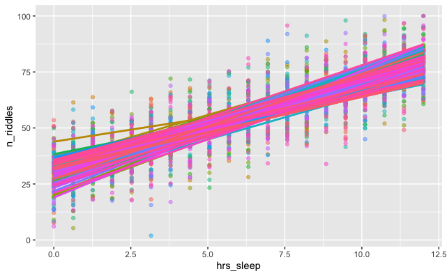

```r
df_ci2 |>
  ggplot(aes(x = hrs_sleep, y = n_riddles, colour = factor(sample_idx))) +
  geom_point(alpha = 0.5) +
  geom_smooth(method = 'lm', se = F) +
  theme(legend.position = 'none')
```

Let’s look at the data from a few different samples.

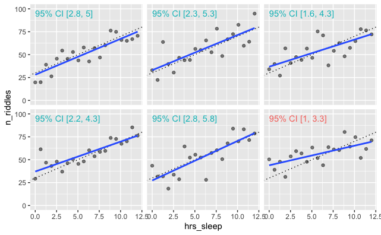

```r
df_confints <- df_confints |>
  mutate(
    pretty_printed = paste0('95% CI [', round(`2.5 %`, 1), ', ', round(`97.5 %`, 1), ']')
  )

first_sample <- 10
last_sample <- first_sample + 5

df_ci2 |>
  filter(sample_idx %in% first_sample:last_sample) |>
  ggplot(aes(x = hrs_sleep, y = n_riddles)) +
  geom_abline(intercept = true_int, slope = true_slope, colour = 'black', linetype = 'dotted') +
  geom_point(alpha = 0.5) +
  geom_smooth(method = 'lm', se = F) +
  geom_text(data = filter(df_confints, sample_idx %in% first_sample:last_sample),
            aes(label = pretty_printed, colour = true_val_in_ci),
            x = 0, y = 95, hjust = 0) +
  facet_wrap(~ factor(sample_idx)) +
  ylim(0, 100) +
  theme(legend.position = 'none',
        # strip.background = element_blank(),
        strip.text = element_blank(),
        ) +
  NULL
```

Another way of looking at that data ^ is just comparing the CIs of the slope to the true value

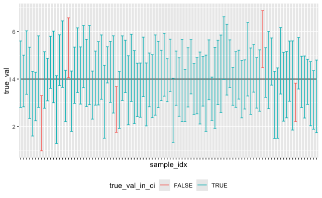

```r
df_confints |>
  mutate(true_val = true_slope) |>
  ggplot(aes(x = sample_idx, y = true_val, group = 1)) +
  geom_line() +
  geom_errorbar(aes(ymin = `2.5 %`, ymax = `97.5 %`, colour = true_val_in_ci)) +
  theme(
    legend.position = 'bottom',
    axis.text.x = element_blank()
    )
```

## plot true line in population

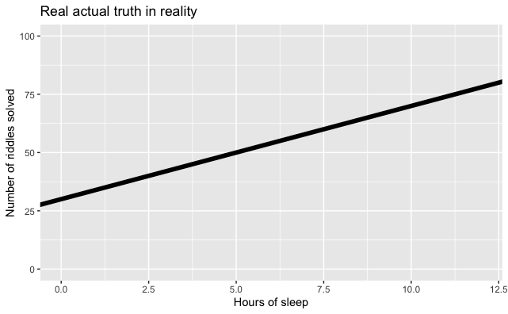

```r
ggplot() +
  geom_abline(intercept = true_int, slope = true_slope, linewidth = 2) +
  xlim(0, 12) +
  ylim(0, 100) +
  labs(
    y = 'Number of riddles solved',
    x = 'Hours of sleep',
    title = 'Real actual truth in reality'
  )
```

# Debunking CI myths + misconceptions

Let’s draw one more sample and pretend that this is our actual experimental sample.

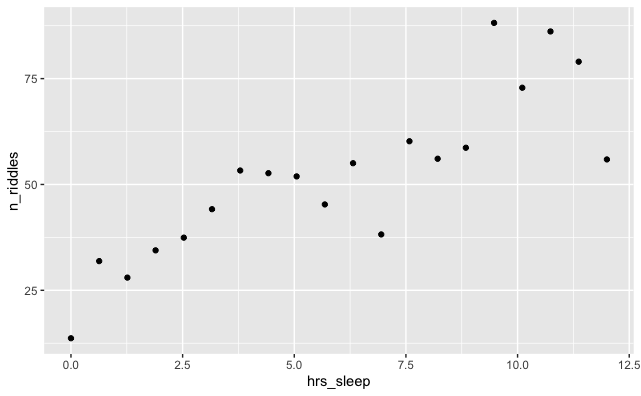

```r
set.seed(150)

expt_sample <- tibble(
  hrs_sleep = seq(0, 12, length.out = n_obs),
  n_riddles = true_int + (true_slope * hrs_sleep) + rnorm(n_obs, 0, 10)
) |>
  mutate(
    n_riddles = case_when(
      n_riddles < 0 ~ 0,
      n_riddles > 100 ~ 100,
      .default = n_riddles
    )
  )

expt_sample |>
  ggplot(aes(x = hrs_sleep, y = n_riddles)) +
  geom_point()
```

```r
m1 <- lm(n_riddles ~ hrs_sleep, data = expt_sample)
confint(m1)['hrs_sleep', ] |> t() |> as.data.frame()
```

| 2.5 % | 97.5 % |
| --- | --- |
| 3.051659 | 5.731164 |

## Debunk: 95% prob that the true value is in CI

nope: the true value IS in the CI in this case, it’s just true. we know it bc we know the pop value. 100% prob bc it is true.

BUT: usually we don’t know the pop value, but we still cannot say with 95% probability that the true value is in CI

confidence != probability

Less good phrasing:

> “We are 95% confident that this interval contains the true mean population”

comment on this phrasing:

> it derives from a flawed understanding of the notion of “confidence” in the statistical sense, and it’s okay, in my opinion the notion of confidence is hard to understand and it is very easy to equate confidence with probability. A more correct interpretation would be, in my opinion, the following: “With a confidence of 95%, we can assert that the population mean is within the interval [x,y]”. It may sound similar to your interpretation, but I think the interpretation I’m suggesting phrases better the notion of confidence as something different from probability

source: [this nice reddit thread](https://www.reddit.com/r/statistics/comments/1je70xr/q_whats_the_point_of_calculating_a_confidence/)

# brilliant CI explanation from reddit

source: [very nice reddit comment](https://www.reddit.com/r/explainlikeimfive/comments/sc5k53/comment/hu4mqf4/?utm_source=share&utm_medium=web3x&utm_name=web3xcss&utm_term=1&utm_content=share_button)

**The “confidence” of a confidence interval refers to the process that generates the intervals. A 95% confidence interval is one generated by a process that constructs 95 intervals that include the true value (the one being estimated) for every 5 that don’t (“on average” or “in the long run”).** (To be clear, generating a new interval implies also collecting a new random sample of the population.)

Importantly, we cannot say for a particular 95% CI that there is a 95% chance that it includes the true value. For a frequentist (the interpretation of probability the CIs are grounded in), that is a statement about three fixed values, so no probability besides 0 and 1 is conceivable: of the times you draw a random sample that has a CI with those bounds, the CI will contain the true value either 0% of the time or 100% of the time. **If you want an interval that has a 95% chance of including the true value, you need a different interpretation of probability (Bayesian instead of frequentist) and different math.**

**link to nhst:**

If you’re familiar with null hypothesis significance testing, you can also think of it in similar terms. **You know what it means when you fail to reject the null? Well the 95% CI is just (usually) the set of values that the null hypothesis could take for which we would fail to reject it at the 5% significance level.**

**In hypothesis testing, when we fail to reject the null hypothesis we don’t accept it. And when we reject the null hypothesis we don’t know how likely it is to be true (or even that it is unlikely to be true).** You could say we decide to act as though the null hypothesis is not true, not as if it’s unlikely to be true. This is done on the basis of having controlled the false positive rate, which is how often we would reject the null hypothesis if it were true. Similarly, we decide to act as though the true value is in the interval, not as if it’s likely to be.

Another way to look at it is with disjunctions like Fisher’s. If the p-value is small enough, we can say that either the null hypothesis is false or something unusual has occurred. **But we cannot say which of these is more likely.** As the xkcd illustrates, it maybe be far more likely that the null hypothesis is true (the sun has not exploded) and something usual has occurred (two 6s) than that the null hypothesis is false (the sun has exploded).

Same logic with confidence intervals: For a sufficiently high confidence CI, either the interval contains the true value or something unusual has occurred.

–

In practice, because the standard error is used to compute confidence intervals, CIs give us a sense of how precise our estimate is. The bigger the CI around the estimated value, the less precise. The smaller the CI around the estimated value, the more precise. **But CIs don’t tell us anything about the probable true value in the real world.**